# NGLVieweR

## Installation

**NGLVieweR** is available through GitHub

```r
install.packages("remotes")
remotes::install_github("nvelden/NGLVieweR")
```

## Loading PDB files

You can load a PDB (or and other supported format) directly or use a PDB code of a structure on [RCSB.org](https://www.rcsb.org/). The below minimal example loads the PDB file and displays the structure in a “cartoon” representation.

```r
#Load local pdb file
NGLVieweR("C:/7CID.pdb") %>%
addRepresentation("cartoon")
#Load protein by PDB code
NGLVieweR("7CID") %>%
addRepresentation("cartoon")
```

**Note:** Use mouse for selection (left-click), rotate/move (left/right-click hold) and zooming (scroll wheel).

[interactive chart not shown]

You can view a “basic” **NGLVieweR** Shiny application by running the below code. Use “API” for an example using API calls or any of the function names (e.g “addSelection”“) for function specific examples.

```r
library(NGLVieweR)
library(shiny)
NGLVieweR_example("basic")
```

## Loading other structural files

This package has been developed and tested using PDB files but supports loading of any of the following structural files: .mmcif, .cif, .mcif, .ent, .pqr, .gro, .sdf, .sd, .mol2 and .mmtf.

By default **NGLVieweR** guesses the file format from the file extension. Use the `format` parameter in case no or the wrong file extension is provided.

```r
#Note that line formatting needs to be exact when reading from console!
benz <- "
702
  -OEChem-02271511112D
  9  8  0     0  0  0  0  0  0999 V2000
    0.5369    0.9749    0.0000 O   0  0  0  0  0  0  0  0  0  0  0  0
    1.4030    0.4749    0.0000 C   0  0  0  0  0  0  0  0  0  0  0  0
    2.2690    0.9749    0.0000 C   0  0  0  0  0  0  0  0  0  0  0  0
    1.8015    0.0000    0.0000 H   0  0  0  0  0  0  0  0  0  0  0  0
    1.0044    0.0000    0.0000 H   0  0  0  0  0  0  0  0  0  0  0  0
    1.9590    1.5118    0.0000 H   0  0  0  0  0  0  0  0  0  0  0  0
    2.8059    1.2849    0.0000 H   0  0  0  0  0  0  0  0  0  0  0  0
    2.5790    0.4380    0.0000 H   0  0  0  0  0  0  0  0  0  0  0  0
    0.0000    0.6649    0.0000 H   0  0  0  0  0  0  0  0  0  0  0  0
  1  2  1  0  0  0  0
  1  9  1  0  0  0  0
  2  3  1  0  0  0  0
  2  4  1  0  0  0  0
  2  5  1  0  0  0  0
  3  6  1  0  0  0  0
  3  7  1  0  0  0  0
  3  8  1  0  0  0  0
M  END
> <ID>
00001
> <DESCRIPTION>
Solvent produced by yeast-based fermentation of sugars.
$$$$
"
NGLVieweR(benz, format="sdf") %>%
  addRepresentation("ball+stick")
```

[interactive chart not shown]

## Representations

```r
NGLVieweR("7CID") %>%
addRepresentation("cartoon") %>%
addRepresentation("ball+stick")
```

You can alter the appearance of select residues using the `param` argument. For a full list of options see the [NGL.js](http://nglviewer.org/ngl/api/) “RepresentationParameters” and the “Selection language” section.

```r
NGLVieweR("7CID") %>%
  addRepresentation("cartoon",
    param = list(colorScheme = "residueindex")
  ) %>%
  addRepresentation("ball+stick",
    param = list(
      sele = "233-248",
      colorValue = "red",
      colorScheme = "element"
    )
  ) %>%
  addRepresentation("surface",
    param = list(
      colorValue = "white",
      opacity = 0.1
    )
  )
```

[interactive chart not shown]

## Structures

Using `addStructure()`, you can load multiple structures into the same stage. In this example, the first structure is represented in blue, while the second representation of the structure is represented in orange. Transformations such as `setPosition()`, `setRotation()`, and `setScale()` apply to the second (most recently added) structure.

```r
NGLVieweR("1CRN") %>%
  addRepresentation("cartoon", param = list(color = "blue")) %>%
  addStructure("1CRN") %>%
  addRepresentation("cartoon", param = list(color = "orange")) %>%
  setPosition(x = 20, y = 0, z = 0) %>%
  setRotation(x = 2, y = 0, z = 0, degrees = FALSE) %>%
  setScale(0.5)
```

[interactive chart not shown]

## Superpose

Structures can be superposed onto each other using the `setSuperpose()` function. It aligns the structures by specifying a reference structure (defaulting to the first one loaded) and defining the selections within each structure to be used for alignment.

```r
NGLVieweR("1GZM") %>%
   addRepresentation("cartoon", param = list(color = "blue")) %>%
   addStructure("1U19") %>%
   addRepresentation("cartoon", param = list(color = "orange")) %>%
   setSuperpose(
     reference = 1,
     sele_reference = ":A",
     sele_target = ":A",
     superpose = TRUE
     )
```

[interactive chart not shown]

## Stage

You can alter the background color or set the zoom or rotation speed using the `stageParameters()` function. For a full list of options, see the “StageParameters” method in the official [NGL.js](http://nglviewer.org/ngl/api/) manual. In additions there are specific functions to set:

- **Animation**: `setRock()` or `setSpin()`
- **Focus**: `setFocus()`
- **Quality**: `setQuality()`

**Note**: Changes in background color are not visible in the RStudio viewer.

```r
NGLVieweR("7CID") %>%
  stageParameters(backgroundColor = "white", zoomSpeed = 1) %>%
  addRepresentation("cartoon",
    param = list(name = "cartoon", colorScheme = "residueindex")
  ) %>%
  setSpin()
```

[interactive chart not shown]

## Labels

Labels can be added by setting the `addRepresentation()` type parameter to “label”. For a full list of of options, see the LabelRepresentationParameters section in the [NGL.js](http://nglviewer.org/ngl/api/) manual. Also see the “label” tab in the [demo](https://niels-van-der-velden.shinyapps.io/shinyNGLVieweR/) app for possible label settings.

```r
NGLVieweR("7CID") %>%
  addRepresentation("cartoon") %>%
  addRepresentation("ball+stick", param = list(
    colorScheme = "element",
    colorValue = "yellow",
    sele = "20"
  )) %>%
  addRepresentation("label",
    param = list(
      sele = "20",
      labelType = "format",
      labelFormat = "[%(resname)s]%(resno)s", # or enter custom text
      labelGrouping = "residue", # or "atom" (eg. sele = "20:A.CB")
      color = "white",
      fontFamiliy = "sans-serif",
      xOffset = 1,
      yOffset = 0,
      zOffset = 0,
      fixedSize = TRUE,
      radiusType = 1,
      radiusSize = 1.5, # Label size
      showBackground = FALSE
      # backgroundColor="black",
      # backgroundOpacity=0.5
    )
  )
```

[interactive chart not shown]

## Transformation functions

The package provides a set of transformation functions that allow for adjusting the scale, rotation, and position of the visualized structures.

### Scaling Structures

The `setScale()` function allows you to adjust the scale of the visualized structure:

```
NGLVieweR("7CID") %>%
addRepresentation("cartoon") %>%
setScale(2) # Doubles the size of the structure
```

### Rotating Structures

You can rotate the visualized structures using the `setRotation()` function:

```
NGLVieweR("7CID") %>%
addRepresentation("cartoon") %>%
setRotation(30, 45, 60) # Rotates the structure 30 degrees around x-axis, 45 degrees around y-axis and 60 degrees around z-axis.
```

### Positioning Structures

The `setPosition()` function allows you to change the position of the visualized structure:

```
NGLVieweR("7CID") %>%
addRepresentation("cartoon") %>%
setPosition(25, 0, 0) # Moves the structure 25 units along the x-axis.
```

## Zoom

You can zoom into specific residues using the `ZoomMove()` function.

```r
NGLVieweR("7CID") %>%
  addRepresentation("cartoon") %>%
  addRepresentation("ball+stick",
    param = list(
      colorScheme = "element",
      colorValue = "yellow",
      sele = "20"
    )
  ) %>%
  addRepresentation("label",
    param = list(
      sele = "20",
      labelType = "format",
      labelFormat = "[%(resname)s]%(resno)s", # or enter custom text
      labelGrouping = "residue", # or "atom" (eg. sele = "20:A.CB")
      color = "white",
      xOffset = 1,
      fixedSize = TRUE,
      radiusType = 1,
      radiusSize = 1.5
    ) # Label size
  ) %>%
  zoomMove(
    center = "20",
    zoom = "20",
    duration = 0, # animation time in ms
    z_offSet = -20
  )
```

[interactive chart not shown]

## Contact

```r
NGLVieweR("3RY2") %>%
  addRepresentation("cartoon") %>%
  addRepresentation("ball+stick",
    param = list(
      name = "biotin",
      colorvalue = "grey",
      colorScheme = "element",
      sele = "5001"
    )
  ) %>%
  addRepresentation("ball+stick",
    param = list(
      name = "interacting",
      colorScheme = "element",
      colorValue = "green",
      sele = "23 or 27 or 43 or 45 or 128"
    )
  ) %>%
  zoomMove(
    center = "27:B",
    zoom = "27:B",
    z_offSet = -20
  ) %>%
  addRepresentation("contact",
    param = list(
      name = "contact",
      sele = "5001 or 23 or 27 or 43 or 45 or 128",
      filterSele = list("23 or 27 or 45 or 128", "5001"),
      labelVisible = TRUE,
      labelFixedSize = FALSE,
      labelUnit = "angstrom", # "", "angstrom", "nm"
      labelSize = 2
      # hydrogenBond=TRUE,
      # weakHydrogenBond=FALSE,
      # waterHydrogenBond=FALSE,
      # backboneHydrogenBond=TRUE,
      # hydrophobic=FALSE,
      # halogenBond=TRUE,
      # ionicInteraction=TRUE,
      # metalCoordination=TRUE,
      # cationPi=TRUE,
      # piStacking=TRUE,
      # maxHydrophobicDist= 4.0,
      # maxHbondDist= 3.5,
      # maxHbondSulfurDist= 4.1,
      # maxHbondAccAngle= 45,
      # maxHbondDonAngle= 45,
      # maxHbondAccPlaneAngle= 90,
      # maxHbondDonPlaneAngle= 30,
      # maxPiStackingDist= 5.5,
      # maxPiStackingOffset= 2.0,
      # maxPiStackingAngle= 30,
      # maxCationPiDist= 6.0,
      # maxCationPiOffset= 2.0,
      # maxIonicDist= 5.0,
      # maxHalogenBondDist= 3.5,
      # maxHalogenBondAngle= 30,
      # maxMetalDist= 3.0,
      # refineSaltBridges= TRUE,
      # masterModelIndex= -1,
      # lineOfSightDistFactor= 1
    )
  )
```

[interactive chart not shown]

## Shiny

The `NGLVieweROutput()` and `renderNGLVieweR()` functions enable you to visualize PDB files within Shiny applications. See the `NGLVieweR_example("basic")` and “API” for live examples.

```r
library(shiny)
library(NGLVieweR)
ui <- fluidPage(NGLVieweROutput("structure"))
server <- function(input, output) {
  output$structure <- renderNGLVieweR({
    NGLVieweR("7CID") %>%
      addRepresentation("cartoon",
        param = list(
          name = "cartoon", color =
            "residueindex"
        )
      ) %>%
      addRepresentation("ball+stick",
        param = list(
          name = "cartoon",
          sele = "1-20",
          colorScheme = "element"
        )
      ) %>%
      stageParameters(backgroundColor = "black") %>%
      setQuality("high") %>%
      setFocus(0) %>%
      setSpin(TRUE)
  })
}
shinyApp(ui, server)
```

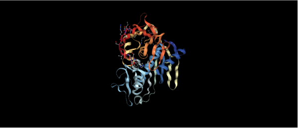

A basic NGLVieweR Shiny app

## API

In Shiny apps, you can manipulate the **NGLVieweR** widget after creation using specific “API” calls. You can for instance add or remove representations by referring to their name using the `addSelection()` or `removeSelection()` functions.

```r
library(shiny)
library(NGLVieweR)

ui <- fluidPage(
  titlePanel("Viewer with API inputs"),
  sidebarLayout(
    sidebarPanel(
      textInput("selection", "Selection", "1-20"),
      selectInput("type", "Type", c("ball+stick", "cartoon", "backbone")),
      selectInput("color", "Color", c("orange", "grey", "white")),
      actionButton("add", "Add"),
      actionButton("remove", "Remove")
    ),
    mainPanel(
      NGLVieweROutput("structure")
    )
  )
)

server <- function(input, output) {
  output$structure <- renderNGLVieweR({
    NGLVieweR("7CID") %>%
      addRepresentation("cartoon",
                        param = list(name = "cartoon", colorScheme = "residueindex")
      ) %>%
      stageParameters(backgroundColor = input$backgroundColor) %>%
      setQuality("high") %>%
      setFocus(0) %>%
      setSpin(TRUE)
  })

  observeEvent(input$add, {
    if (isolate(input$type) == "cartoon") {
      # For cartoon, use the color parameter
      NGLVieweR_proxy("structure") %>%
        addSelection(isolate(input$type),
                     param = list(
                       name = "sel1",
                       sele = isolate(input$selection),
                       color = isolate(input$color)
                     )
        )
    } else {
      # For other types, use colorValue
      NGLVieweR_proxy("structure") %>%
        addSelection(isolate(input$type),
                     param = list(
                       name = "sel1",
                       sele = isolate(input$selection),
                       colorValue = isolate(input$color)
                     )
        )
    }
  })

  observeEvent(input$remove, {
    NGLVieweR_proxy("structure") %>%
      removeSelection("sel1")
  })
}

shinyApp(ui, server)
```

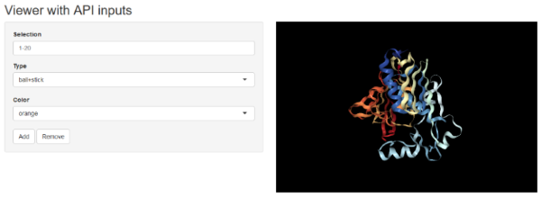

NGLVieweR API in Shiny

### Possible API functions are:

- `addSelection()`
- `removeSelection()`
- `snapShot()`
- `updateColor()`
- `updateFocus()`
- `updateFullscreen()`
- `updateRepresentation()`
- `updateRock()`
- `updateSelection()`
- `updateSpin()`
- `updateStage()`
- `updateVisibility()`
- `updateZoomMove()`

## Retrieving data from the widget

In a Shiny application one can retrieve information from the widget as inputs based on the NGLVieweR `outputID`. Suppose the `outputID` is “structure”, then the following information can be retrieved:

- input$structure_selection - Get details on the clicked residue.
- input$structure_sequence - will return the sequence of the PDB file as a character vector.
- input$structure_resno - will return all the sequence numbers as a numeric vector.
- input$structure_chainname - will return the chainname of each amino acid as a character vector,
- input$structure_rendering - will return `TRUE` if the widget is loading or `FALSE` when completed.
- input$structure_PDB - will return the PDB file as a text string.
- input$structure_selAround - will return a list of atoms surrounding a clicked residue.

In the below example a label, all contacts and residues in proximity of the clicked residue are displayed.

```r
library(shiny)
library(NGLVieweR)
library(stringr)

ui <- fluidPage(
  titlePanel("Viewer with click interaction"),
  sidebarLayout(
    sidebarPanel(verbatimTextOutput('selection')),
    mainPanel(NGLVieweROutput("structure"))
  )
)

server <- function(input, output) {
  output$structure <- renderNGLVieweR({
    NGLVieweR("3RY2") %>%
      addRepresentation("cartoon") %>%
      addRepresentation(
        "ball+stick",
        param = list(
          name = "biotin",
          colorvalue = "grey",
          colorScheme = "element",
          sele = "5001"
        )
      ) %>%
      zoomMove(center = "27:B",
               zoom = "27:B",
               z_offSet = -20) %>%
      selectionParameters(3, "residue") #"atom"
  })

  #Save click selections
  sele <- reactiveValues()

  observe({
    sele$aa <-
      str_extract(input$structure_selection, "(?<=[\\[])(.*?)(?=\\])")
    sele$aa_bond <-
      str_extract(input$structure_selection, "(?<=[\\]])(.*?)(?=[:space:])")
    sele$resiChain <-
      str_extract(input$structure_selection, "(?<=[]])(.*?)(?=[.])")
    sele$resi <-
      str_extract(input$structure_selection, "(?<=[]])(.*?)(?=[:])")
    sele$fileName <-
      str_extract(input$structure_selection, "(?<=[(])(.*?)(?=[.])")
  })

  output$selection = renderPrint({
    #Full selection
    print(input$structure_selection)
    #Amino Acid
    print(sele$aa)
    #Bond
    print(sele$aa_bond)
    #Residue number + ChainNAme
    print(sele$resiChain)
    #Residue number
    print(sele$resi)
    #PDB name
    print(sele$fileName)
    #SelAround
    print(input$structure_selAround)
  })

  observeEvent(input$structure_selAround, {
    NGLVieweR_proxy("structure") %>% removeSelection("selAround")

    NGLVieweR_proxy("structure") %>%
      addSelection(
        "ball+stick",
        param =
          list(
            name = "selAround",
            sele = input$structure_selAround,
            colorValue = "grey"
          )
      )

  })

  observeEvent(sele$resiChain, {
    #Remove any selections
    NGLVieweR_proxy("structure") %>% removeSelection("label")
    NGLVieweR_proxy("structure") %>% removeSelection("contact")

    #Add label and contacts
    NGLVieweR_proxy("structure") %>%

      addSelection(
        "label",
        param = list(
          name = "label",
          sele = sele$resiChain,
          labelType = "format",
          labelFormat = "[%(resname)s]%(resno)s",
          # or enter custom text
          labelGrouping = "residue",
          # or "atom" (eg. sele = "20:A.CB")
          color = "white",
          xOffset = 1,
          fixedSize = TRUE,
          radiusType = 1,
          radiusSize = 1.5
        )
      ) %>%
      addSelection(
        "contact",
        param = list(
          name = "contact",
          sele = "*",
          #Select all residues
          filterSele =
            list(sele$resiChain, # Show bonds between selected residue
                 "*"),
          # and all other residues
          labelVisible = TRUE,
          labelFixedSize = FALSE,
          labelUnit = "angstrom",
          # "", "angstrom", "nm"
          labelSize = 2
        )
      )
  })

}
shinyApp(ui, server)
```

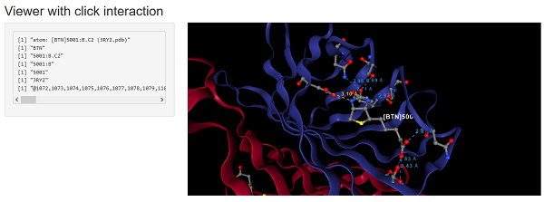

Click interaction example in NGLVieweR